# Text mining: Plan de recuperación Covid-19 UE

Jose Antonio Espejel Muñoz

[figure not shown]

# Fondo europeo Covid-19

El objetivo es analizar las medidas tomadas bajo el instrumento de recuperación denominado NGEU (Next Generation EU) para combatir las consecuencias adversas provocadas por la pandemia del Covid-19 y su integración en el Marco Financiero Plurianual de la Unión Europea.

Para ello se analizarán, por una parte, el plan que la Comisión estableció el 28 de mayo de 2020, basado en la solidaridad inspirada por los principios y valores comunes de la Unión Europea y por otra parte el acuerdo alcanzado la madrugada del 21 de Julio de 2020.

Se examinarán las primeras respuestas en las redes sociales, a través de los servicios de microblogging de Twitter. Resaltar que estas opiniones presentan un sesgo hacia los usuarios de las redes sociales más jóvenes, entre 18 y 24 años. En este grupo de edad el 45% usa Twitter comparado con el 33% entre 25 y 29 años, el 27% entre 30 y 49 años y el 19% entre 50 y 64 años. Los usuarios universitarios son más propensos a usar Twitter, así como, los que tienen mayor poder adquisitivo y viven en la ciudad.

# Análisis de los documentos

Con el análisis automático de los documentos pretendemos obtener conocimiento acerca del asunto o pensamiento del documento sin leerlo. Para ello utilizaremos la capacidad para gestionar documentos provisto en el paquete tm[^1] (*t*ext *m*ining) desarrollado por Ingo Feinerer. En la modelación del tema o tópico se utilizará la librería *stm*[^2] de modelado de tema estructural desarrollada en el MIT.

## Preparación del entorno

Se comprueban dependencias y se cargan librerías en memoria.

```r
# instalamos httpuv si no se ha instalado previamente para la autenticacion en Tweeter
if (!requireNamespace("httpuv", quietly = TRUE)) {
  install.packages("httpuv")
}
if (!requireNamespace("reshape2", quietly = TRUE)) {
  install.packages("reshape2")
}
# Cargamos en el entorno las librerias necesarias suprimiendo los mensajes de diagnostico en la carga
suppressPackageStartupMessages({
  library(rtweet)       #conexion con la API de Twitter
  library(stm)          #modelado del topico
  library(tm)           #funciones de text mining, lectura pdf
  library(sentimentr)   #sentiment analisis de tweets
  library(wordcloud)    #representacion visual palabras mas frecuentes
  library(RColorBrewer) #paleta de colores
  library(plyr)         #funciones avanzadas pipelines
  library(ggplot2)      #graficos - bar
  library(knitr)        #markdown
  library(data.table)   #datatable
  library(reshape2)     #funcion acast tweets
  library(tidyverse)    #inner-join
  library(httpuv)       #Autenticar via web
})

#limpiamos las variables de entorno
rm(list = ls())
```

## ETL **PROPUESTA**

### **E**TL - Extract

En primer lugar, cargamos en memoria la propuesta del Consejo de la Unión Europea para apoyar la recuperación tras la pandemia del Covid-19.[^3] Para ello se lee directamente el pdf original, almacenado en el directorio data, con la función *readPDF* de la librería *tm*. A continuación, examinamos los metadatos del documento.

```r
my_uri <- "./data/CELEX_52020PC0441R(01)_Covid19_EN_TXT.pdf"
# Leemos
pdf_doc <- readPDF(control=list(text='-enc "UTF-8"'))(elem = list(uri = my_uri), language="en")
```

```r
pdf_doc$meta
```

```
##   author       :
##   datetimestamp: 2020-05-28 13:39:56
##   description  :
##   heading      :
##   id           : CELEX_52020PC0441R(01)_Covid19_EN_TXT.pdf
##   language     : en
##   origin       : PDF CoDe 2018 4.7111.7111 (c) 2002-2018 European Commission
```

Observamos que se trata de un documento en inglés, del 28 de mayo de 2020, sin descripción ni encabezado ni autor. La plantilla usada es Copyright (c) de la Comisión Europea 2002-2018 y el documento tiene id del departamento legal de la Comisión Europea.

```r
cat("Número de páginas: ", length(pdf_doc$content))
```

```
## Número de páginas:  28
```

```
## Visualizamos las dos primeras para hacernos una idea de las transformaciones que deberemos realizar
```

```r
head(pdf_doc$content, 2)
```

```
## [1] "                              EUROPEAN\n                              COMMISSION\n\n\n\n\n                                                     Brussels, 28.5.2020\n                                                     COM(2020) 441 final/2\n\n                                                  …
## [2] "                                  EXPLANATORY MEMORANDUM\n\n     1.       CONTEXT OF THE PROPOSAL\n     •        Reasons for and objectives of the proposal\n     The COVID-19 pandemic constitutes a widespread and severe public health crisis. It severely\n     affects citizens, societies and …
```

Extraemos el texto propiamente dicho del documento como un conjunto de líneas mediante la función *content()*. Como se ha podido apreciar, en las líneas aparecen caracteres especiales, muchas en blanco y otros elementos que será necesario filtrar como parte del procesamiento.

```r
pdf_texto <- content(pdf_doc)
```

### E**T**L - Transform

Para automatizar transformación de los datos, creamos dos funciones, *clean.txt* y *corpus.clean*.

En la primera, nos basaremos en la función base de R *gsub* y en expresiones regulares[^4] que utilizaremos para limpiar variables tipo caracter. Para la segunda, en la que limpiaremos un corpus (una lista de clase SimpleCorpus), realizaremos transformaciones mediante las funciones provistas en el paquete *tm.*

Función *clean.txt(x)*:

```r
clean.txt <- function(x){

  # Eliminamos lineas vacias
  x <- x[x != ""]

  # Eliminamos caracteres especiales e.g secuencia escape tabulador horizontal
  x <- gsub("\a|\t|\r|\n", "", x)   # Eliminamos tabulador horizontal, retorno de carro, nueva linea
  x <- gsub("/"," ",x)              # Elimina '/' entre palabras e.g proposal/initiative
  x <- gsub("(<[^>]*>)", "", x)     # Quitamos el código html de los links
  x <- gsub("\\W"," ",x)            # Quitamos caracteres de subatitucion de casillas de verificacion
  x <- gsub("\\bX\\b"," ",x)        # Ticks de verificacion (formulario)
  return(x)
}
```

```r
pdf_texto <- clean.txt(pdf_texto)
```

Ahora podemos buscar dentro del texto usando la función *grep*, por ejemplo, la palabra **covid**, ignorando mayúsculas, minúsculas, etcétera, que es una palabra que esperábamos apareciera en numerosas ocasiones.

```r
index_covid <- grep("\\Wcovid\\W", pdf_texto, ignore.case = TRUE, perl = TRUE)
```

Hemos creado un objeto, index_covid, que apunta a las páginas donde aparece la palabra covid, con un total de 11 páginas.

Páginas donde aparece: 1, 2, 3, 6, 7, 8, 9, 13, 14, 15, 16.

### Corpus

Examinando la importancia de las palabras contenidas en el documento, trataremos de identificar el asunto o tema tratado.

Una medida de la importancia de una palabra puede ser su término de frecuencia, es decir, la frecuencia con la que aparece en el documento. Sin embargo, existen palabras que, aún teniendo una frecuencia alta, no son relevantes para nuestro propósito como puedan ser artículos, preposiciones, etcétera. Siguiendo este criterio se eliminarán en primer lugar las palabras que no consideremos significativas.

En cualquier caso, es siempre interesante crear un corpus de *tm* que nos permita realizar operaciones de minería de texto; usamos la función *Corpus*:

```r
corpus <- Corpus(VectorSource(pdf_texto), readerControl = list(language = "en"))
corpus
```

```
## <<SimpleCorpus>>
## Metadata:  corpus specific: 1, document level (indexed): 0
## Content:  documents: 28
```

Una vez creado el corpus, realizamos transformaciones en este mediante la función *tm_map* que aplica o mapea una función a todos los elementos del corpus.

Creamos la función *corpus.clean* para limpiar el corpus en la que:

1. Quitaremos los espacios en blanco.
2. Pasaremos a minúsculas.
3. Eliminaremos los signos de puntuación.
4. Suprimiremos los números.
5. Eliminaremos las “stopwords”
6. Convertiremos a texto plano.

Previamente añadimos a la lista de palabras a eliminar en el *stopwords*, términos que hemos observado aparecen con frecuencia, pero que no aportan significado al estudio y no se encuentran en el conjunto de stopwords en inglés.

Actualmente en el diccionario inglés:

- i, me, my, myself, we, our, ours, ourselves, you, your, yours, yourself, yourselves, he, him, his, himself, she, her, hers, herself, it, its, itself, they, them, their, theirs, themselves, what, which, who, whom, this, that, these, those, am, is, are, was, were, be, been, being, have, has, had, having, do, does, did, doing, would, should, could, ought, i’m, you’re, he’s, she’s, it’s, we’re, they’re, i’ve, you’ve, we’ve, they’ve, i’d, you’d, he’d, she’d, we’d, they’d, i’ll, you’ll, he’ll, she’ll, we’ll, they’ll, isn’t, aren’t, wasn’t, weren’t, hasn’t, haven’t, hadn’t, doesn’t, don’t, didn’t, won’t, wouldn’t, shan’t, shouldn’t, can’t, cannot, couldn’t, mustn’t, let’s, that’s, who’s, what’s, here’s, there’s, when’s, where’s, why’s, how’s, a, an, the, and, but, if, or, because, as, until, while, of, at, by, for, with, about, against, between, into, through, during, before, after, above, below, to, from, up, down, in, out, on, off, over, under, again, further, then, once, here, there, when, where, why, how, all, any, both, each, few, more, most, other, some, such, no, nor, not, only, own, same, so, than, too, very

Añadimos los términos:

- shall , per, will

```r
# Se añaden las siguientes palabras:

my_stopwords <- c('shall','per','will')

stopwords <- c(my_stopwords, stopwords(kind = 'en'))
```

Creamos la función *corpus.clean(x)*

```r
corpus.clean <- function(x){
  # Quitamos los espacios en blanco
  cp <- tm_map(x, stripWhitespace)

  # Pasamos a minúsculas.
  cp <- tm_map(cp,tolower)

  # Eliminamos los signos de puntuación
  cp <- tm_map(cp, removePunctuation)

  # Suprimimos los números
  cp <- tm_map(cp, removeNumbers)

  # Quitamos los stopwords en inglés (lang)
  cp <- tm_map(cp,removeWords, stopwords)
  return(cp)
}
```

Limpiamos el corpus

```r
corpus <- corpus.clean(corpus)
```

Comprobamos las modificaciones en la página 2 visualizada anteriormente.

```r
inspect(corpus[2])
```

```
## <<SimpleCorpus>>
## Metadata:  corpus specific: 1, document level (indexed): 0
## Content:  documents: 1
##
## [1]  explanatory memorandum  context   proposal reasons   objectives   proposal  covid  pandemic constitutes  widespread  severe public health crisis  severely affects citizens societies  economies worldwide  extent   health crisis   policy responses taken  control   unprecedented   result  depth…
```

### Matriz DTM

A través del corpus, limpio de términos en los que no estamos interesados, creamos una matriz con documentos por fila, en este caso 28 páginas, y términos por columnas (*D*ocument*T*erm*M*atrix). Este documento, nos facilitará el cómputo y la representación gráfica de la frecuencia de las palabras “importantes” mediante una nube de palabras.

```r
pdf_dtm <- DocumentTermMatrix(corpus)
pdf_dtm
```

```
## <<DocumentTermMatrix (documents: 28, terms: 1086)>>
## Non-/sparse entries: 2786/27622
## Sparsity           : 91%
## Maximal term length: 20
## Weighting          : term frequency (tf)
```

Tenemos por lo tanto una dimensión de:

- 28 documentos que aparecen como *Docs* y como filas *nrow* en el DTM que denominamos pdf_dtm.
- 1086 términos que aparecen como *Terms* y como columnas *ncol* en el DTM.

Es decir, tras la pequeña limpieza de los términos en el corpus obtenemos una matriz dispersa de 28 documentos y 1086 términos distintos.

## Nube de Palabras

Como el documento no es muy grande, generamos una lista de términos con una frecuencia absoluta mínima de 15. En esta ocasión vamos a usar la función *findFreqTerms* del paquete *tm*

```r
ft <- findFreqTerms(pdf_dtm, 15)
```

Representamos gráficamente mediante un wordcloud o *nube de palabras*. De esta manera podemos de un simple vistazo ver los términos principales del documento.

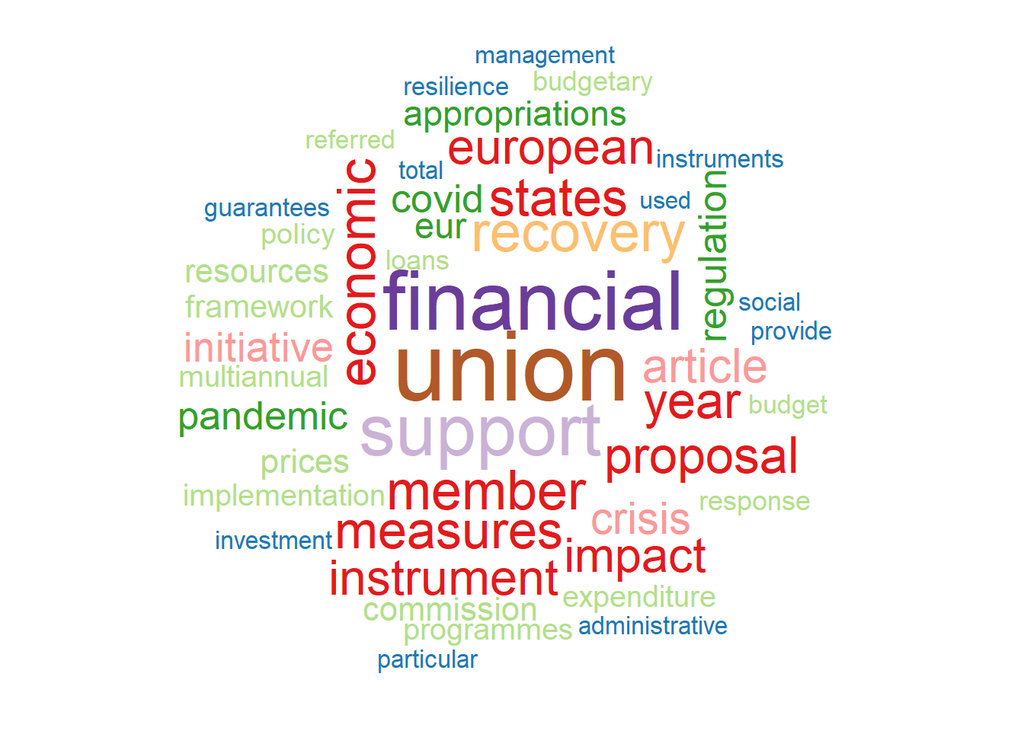

```r
wordcloud(corpus, min.freq = 15, random.order = FALSE, colors = brewer.pal(12, "Paired"))
```

De manera ilustrativa vemos el peso de cada palabra según su tamaño en la nube. Podemos concluir que el documento en general hace hincapié en el apoyo financiero de la Unión europea para recuperarse del impacto de la pandemia covid.

Una vez tenemos el DTM, en lugar de crear un TDM para representar un diagrama de frecuencias, transformamos el DTM en forma matricial y para facilitarnos la representación gráfica a dataframe.

```r
# Lo convertimos en matriz
t<- sort(colSums(as.matrix(pdf_dtm)), decreasing = TRUE)

# Y creamos el objeto como dataframe
dtm_matriz  <- data.frame(word=names(t), freq=t)

head(dtm_matriz, 20)
```

```
##                  word freq
## union           union  104
## financial   financial   85
## support       support   73
## recovery     recovery   54
## member         member   52
## economic     economic   50
## measures     measures   48
## states         states   48
## proposal     proposal   47
## year             year   46
## european     european   45
## instrument instrument   45
## impact         impact   44
## article       article   43
## crisis         crisis   39
## initiative initiative   35
## covid           covid   33
## regulation regulation   33
## pandemic     pandemic   33
## eur               eur   29
```

Gráficamente

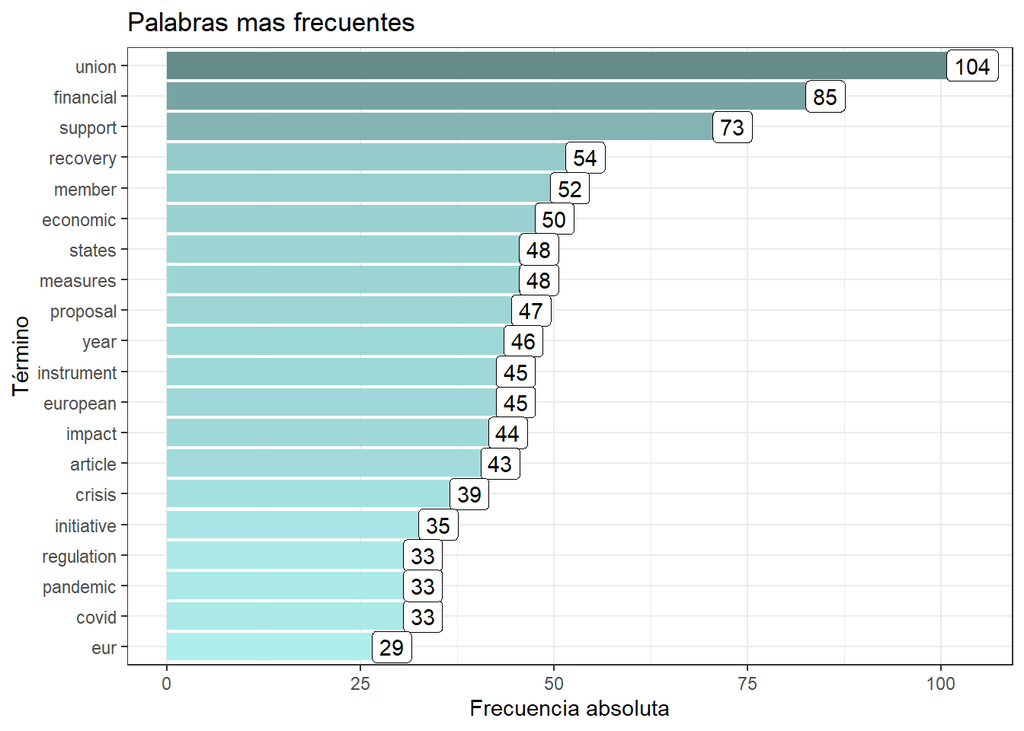

```r
ggplot(dtm_matriz[1:20,], aes(x=reorder(dtm_matriz[1:20, ]$word,dtm_matriz[1:20, ]$freq), y=dtm_matriz[1:20, ]$freq)) +
  geom_bar(stat="identity", aes(fill=dtm_matriz[1:20, ]$freq), show.legend=FALSE) +
  geom_label(aes(label=paste0(round(dtm_matriz[1:20, ]$freq*1, 2), ""))) +
  scale_fill_gradient(low="paleturquoise", high="paleturquoise4") +
  labs(x="Término", y="Frecuencia absoluta",
       title="Palabras mas frecuentes") +
  coord_flip() +
  theme_bw()
```

## Modelado de tópicos

Tal y como apuntamos en la introducción del Análisis de documentos, para la modelación del tópico utilizaremos la función *stm*. Dado que ya tenemos un DTM no necesitaremos crear un dfm. Sin embargo, si que será necesaria una transformación mediante la función *readCorpus*.

Como parámetro de la función *stm*, que realiza el modelado, está el número de bloques o cluster *K* que queremos, en nuestro caso 3. Es decir, queremos que divida el texto o documento completo en tres tópicos con las palabras asociadas a cada uno de ellos o más próximas a ellos según la métrica utilizada por el algoritmo (kmeans). Utilizamos una inicialización determinista usando el algoritmo “spectral” que presenta un buen rendimiento con menos de 10.000 elementos.

```r
out <- readCorpus(pdf_dtm, type="slam")
documents <- out$documents
vocab <- out$vocab
out <- prepDocuments(documents, vocab, meta=NULL)
```

```
## Removing 534 of 1086 terms (534 of 2786 tokens) due to frequency
## Your corpus now has 28 documents, 552 terms and 2252 tokens.
```

```r
topic_model <- stm(documents, vocab, K = 3, verbose = FALSE, init.type = "Spectral")
```

```r
summary(topic_model)
```

```
## A topic model with 3 topics, 28 documents and a 1086 word dictionary.
```

```
## Topic 1 Top Words:
##       Highest Prob: payments, staff, financial, resources, commission, external, management
##       FREX: payments, staff, delegations, debt, int, end, period
##       Lift: payments, appropriation, arrangements, elements, entails, excluding, expected
##       Score: payments, int, staff, coupon, cover, human, redemptions
## Topic 2 Top Words:
##       Highest Prob: year, initiative, proposal, financial, multiannual, framework, impact
##       FREX: total, heading, estimated, initiative, framework, multiannual, operational
##       Lift: heading, contributions, estimated, mode, party, planned, revenueen
##       Score: heading, total, estimated, year, decimal, million, places
## Topic 3 Top Words:
##       Highest Prob: union, support, recovery, financial, economic, member, measures
##       FREX: recovery, european, instrument, crisis, covid, pandemic, prices
##       Lift: com, covid, document, final, consequences, different, digital
##       Score: recovery, european, pandemic, covid, crisis, resilience, instrument
```

De una forma similar, mediante una exploración de la agrupación de las palabras en los distintos tópicos, independientemente de la medida en la que nos fijemos, la máxima probabilidad, frecuencia y exclusividad o las medidas de otros paquetes de text-mining populares como Lift y Score, vemos que en general:

- El *Topic 1* tiene que ver con pago, personal, recursos humanos.
- El *Topic 2* nos habla de la propuesta financiera dentro del marco multianual
- El *Topic 3* trata de la recuperación económica de la Unión Europea causada por la crisis de la pandemia covid

Podemos visualizar individualmente cada tópico. Por ejemplo, para el tópico 2 tenemos:

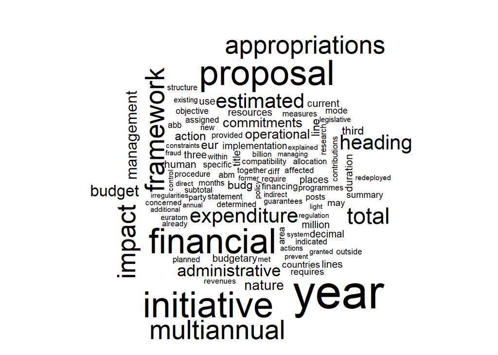

```r
cloud(topic_model, topic = 2, type = c("model", "documents"), documents,
thresh = 0.9, max.words = 100)
```

Vemos de forma gráfica los tres temas por frecuencia de palabras

```r
# Creamos un td_beta como tidy tibble de topic_model
library(tidyr)
library(tidytext)
td_beta <- tidy(topic_model)
```

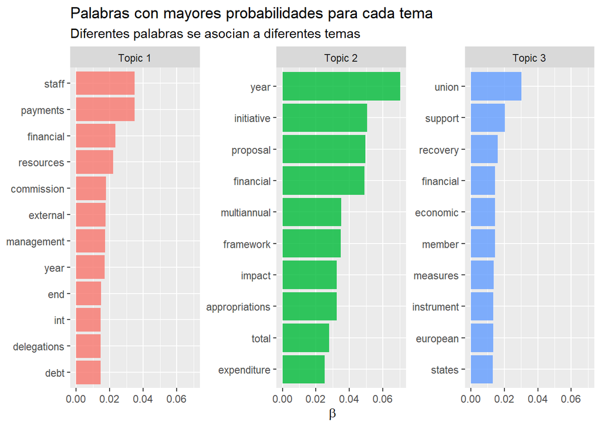

```r
library(dplyr)
td_beta %>%

    # Agrupamos por topic
    group_by(topic) %>%

    # Nos quedamos con los top n (10) sobre el valor de beta
    top_n(10, beta) %>%

    # Desagrupamos
    ungroup() %>%

    # Cambiamos y reordenamos. Tres columnas: topic, term, beta
    mutate(topic = paste0("Topic ", topic),
           term = reorder_within(term, beta, topic)) %>%

    # Creamos un gráfico
    ggplot(aes(term, beta, fill = as.factor(topic))) +
    geom_col(alpha = 0.8, show.legend = FALSE) +
    facet_wrap(~ topic, scales = "free_y") +
    coord_flip() +
    scale_x_reordered() +
    labs(x        = NULL,
         y        = expression(beta),
         title    = "Palabras con mayores probabilidades para cada tema",
         subtitle = "Diferentes palabras se asocian a diferentes temas")
```

## ETL **CONCLUSIONES**

### **E**TL - Extract

Cargamos en memoria el archivo pdf de las conclusiones adoptadas por el Consejo de la Unión Europea dentro del marco financiero multianual para apoyar la recuperación después de la pandemia del Covid-19 tras la reunión mantenida hasta la madrugada del 21 de julio de 2020.[^5]

Se lee directamente el pdf original, almacenado en el directorio data, con la función *readPDF* y se continua con los procedimientos seguidos en el ETL de la propuesta.

```r
my_uri <- "./data/210720-euco-final-conclusions-en.pdf"
# Leemos
pdf_doc <- readPDF(control=list(text='-enc "UTF-8"'))(elem = list(uri = my_uri), language="en")
```

```r
pdf_doc$meta
```

```
##   author       : PIGEON Supattra
##   datetimestamp: 2020-07-21 05:06:00
##   description  :
##   heading      :
##   id           : 210720-euco-final-conclusions-en.pdf
##   language     : en
##   origin       : Acrobat PDFMaker 20 for Word
```

En este caso se trata de un pdf creado con PDFMaker por PIGEON Supattra en inglés. Extraemos el contenido.

```r
pdf_texto <- content(pdf_doc)
```

### E**T**L - Transform

Limpiamos el texto con la función creada *clean.txt*

```r
pdf_texto <- clean.txt(pdf_texto)
```

Creamos un corpus, lo limpiamos y visualizamos el número de documentos que en nuestro caso serán páginas.

```r
(corpus <- corpus.clean(Corpus(VectorSource(pdf_texto), readerControl = list(language = "en"))))
```

```
## <<SimpleCorpus>>
## Metadata:  corpus specific: 1, document level (indexed): 0
## Content:  documents: 68
```

Creamos un DTM

```r
pdf_dtm <- DocumentTermMatrix(corpus)
```

## Nube de Palabras

Encontramos las palabras con una frecuencia absoluta mínima de 15.

```r
(ft <- findFreqTerms(pdf_dtm, 15))
```

```
##   [1] "conclusions"    "council"        "euco"           "eur"
##   [5] "european"       "july"           "basis"          "commission"
##   [9] "covid"          "crisis"         "economic"       "europe"
##  [13] "financial"      "level"          "may"            "measures"
##  [17] "member"         "mff"            "ngeu"           "recovery"
##  [21] "resilience"     "specific"       "state"          "states"
##  [25] "union"          "accordance"     "additional"     "based"
##  [29] "digital"        "first"          "funds"          "instruments"
##  [33] "investment"     "jobs"           "order"          "priorities"
##  [37] "programmes"     "provide"        "public"         "regions"
##  [41] "set"            "social"         "support"        "amount"
##  [45] "amounts"        "billion"        "ensure"         "exceed"
##  [49] "expenditure"    "management"     "maximum"        "new"
##  [53] "payments"       "percentage"     "prices"         "resources"
##  [57] "used"           "year"           "applicable"     "budget"
```

[output cut: 19 more lines]

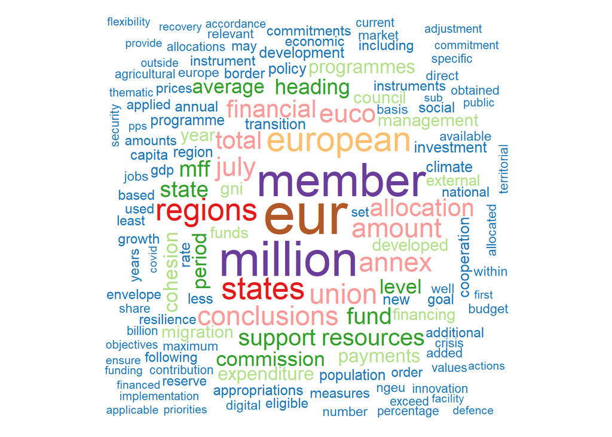

```r
wordcloud(corpus, min.freq = 15, random.order = FALSE, colors = brewer.pal(12, "Paired"))
```

Construimos una tabla de frecuencias y la representamos gráficamente:

```r
# Lo convertimos en matriz
t<- sort(colSums(as.matrix(pdf_dtm)), decreasing = TRUE)

# Y creamos el objeto como dataframe
tdm_matriz  <- data.frame(word=names(t), freq=t)

head(tdm_matriz, 20)
```

```
##                    word freq
## eur                 eur  179
## million         million  145
## member           member  136
## european       european   96
## states           states   85
## regions         regions   84
## union             union   74
## conclusions conclusions   71
## amount           amount   70
## july               july   69
## annex             annex   68
## euco               euco   66
## financial     financial   61
## allocation   allocation   61
## total             total   60
## fund               fund   58
## support         support   57
## resources     resources   57
## mff                 mff   54
## state             state   53
```

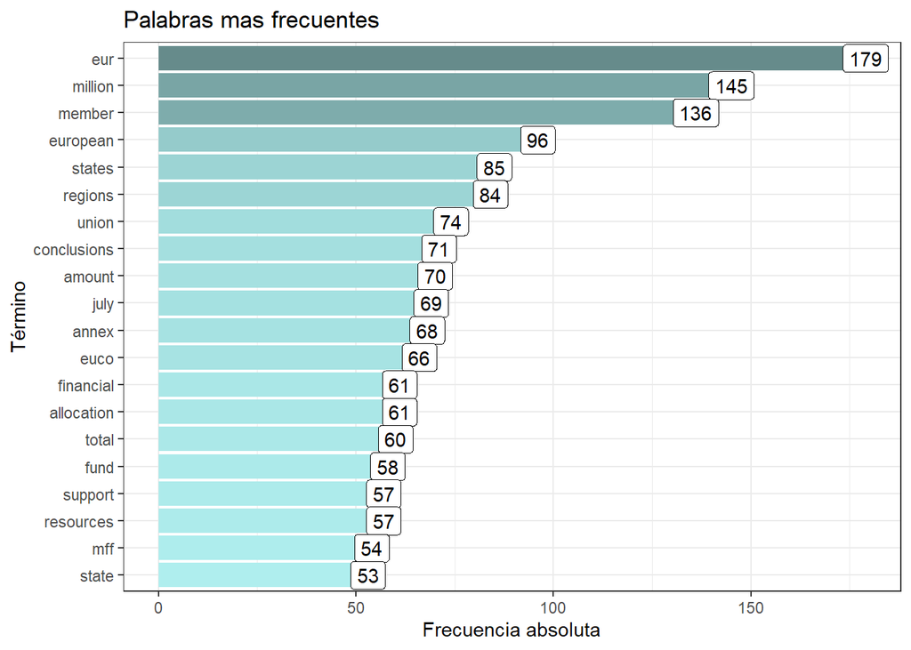

```r
ggplot(tdm_matriz[1:20,], aes(x=reorder(tdm_matriz[1:20, ]$word,tdm_matriz[1:20, ]$freq), y=tdm_matriz[1:20, ]$freq)) +
  geom_bar(stat="identity", aes(fill=tdm_matriz[1:20, ]$freq), show.legend=FALSE) +
  geom_label(aes(label=paste0(round(tdm_matriz[1:20, ]$freq*1, 2), ""))) +
  scale_fill_gradient(low="paleturquoise", high="paleturquoise4") +
  labs(x="Término", y="Frecuencia absoluta",
       title="Palabras mas frecuentes") +
  coord_flip() +
  theme_bw()
```

Se trata de recurso EUCO dentro del marco financiero multianual y por lo tanto engloba temas medioambientales (climate), agropecuarios, etcétera.

## Modelado de tópicos

```r
out <- readCorpus(pdf_dtm, type="slam")
documents <- out$documents
vocab <- out$vocab
out <- prepDocuments(documents, vocab, meta=NULL)
```

```
## Removing 803 of 1708 terms (803 of 5898 tokens) due to frequency
## Your corpus now has 68 documents, 905 terms and 5095 tokens.
```

```r
topic_model <- stm(documents, vocab, K = 3, verbose = FALSE, init.type = "Spectral")
```

```r
summary(topic_model)
```

```
## A topic model with 3 topics, 68 documents and a 1708 word dictionary.
```

```
## Topic 1 Top Words:
##       Highest Prob: european, union, mff, council, conclusions, commission, july
##       FREX: decision, framework, emergency, budgetary, interests, policies, respond
##       Lift: general, exceptional, decision, abovemeeting, adopted, attached, brussels
##       Score: council, emergency, targets, assessment, fulfilment, milestones, satisfactory
## Topic 2 Top Words:
##       Highest Prob: million, eur, fund, heading, support, member, cohesion
##       FREX: agricultural, facility, strategic, eafrd, rural, asylum, pillar
##       Lift: investments, research, contributing, cef, horizon, paid, prefinancing
##       Score: agricultural, million, heading, external, direct, security, eafrd
## Topic 3 Top Words:
##       Highest Prob: member, regions, allocation, state, average, developed, eur
##       FREX: population, region, gdp, applied, obtained, pps, gross
##       Lift: unemployment, resource, unemployed, determined, emissions, head, intensity
##       Score: population, applied, obtained, region, developed, pps, unemployed
```

De forma gráfica

```r
# Creamos un td_beta como tidy tibble de topic_model
library(tidyr)
library(tidytext)
td_beta <- tidy(topic_model)
```

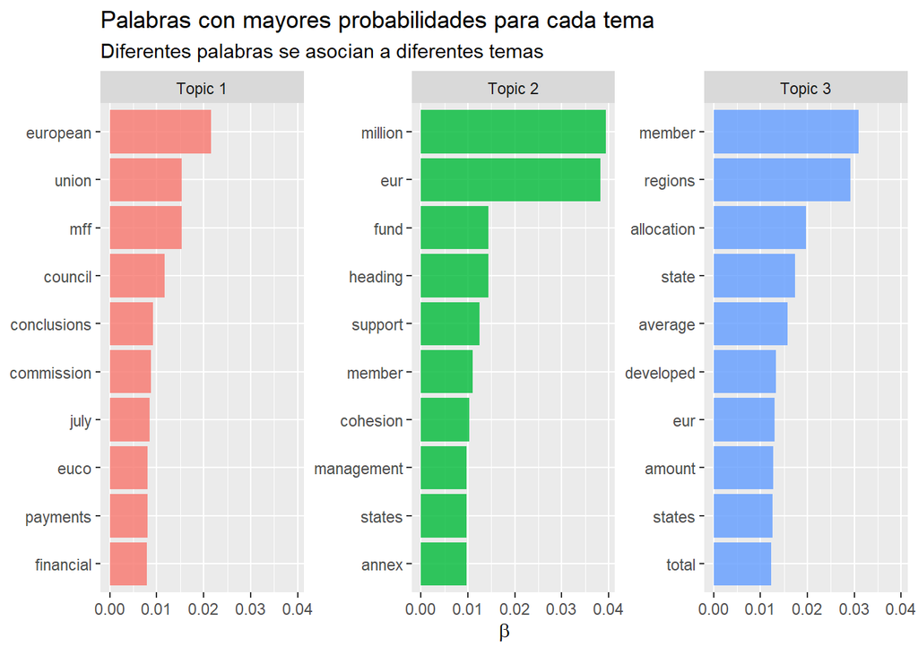

```r
library(dplyr)
td_beta %>%

    # Agrupamos por topic
    group_by(topic) %>%

    # Nos quedamos con los top n (10) sobre el valor de beta
    top_n(10, beta) %>%

    # Desagrupamos
    ungroup() %>%

    # Cambiamos y reordenamos. Tres columnas: topic, term, beta
    mutate(topic = paste0("Topic ", topic),
           term = reorder_within(term, beta, topic)) %>%

    # Creamos un gráfico
    ggplot(aes(term, beta, fill = as.factor(topic))) +
    geom_col(alpha = 0.8, show.legend = FALSE) +
    facet_wrap(~ topic, scales = "free_y") +
    coord_flip() +
    scale_x_reordered() +
    labs(x        = NULL,
         y        = expression(beta),
         title    = "Palabras con mayores probabilidades para cada tema",
         subtitle = "Diferentes palabras se asocian a diferentes temas")
```

# Análisis de Tweets

Tal y como se mencionó en la introducción, se pretende examinar las primeras respuestas en las redes sociales a través de Twitter. Por una parte, para ver si los temas fundamentales recogidos en los documentos son de alguna forma importantes para la población, desde el punto de vista que se habla y discute de ello, y por otra parte, si la opinión sobre las conclusiones son en general positivas o negativas.

## ETL Tweets

### **E**TL - Extract

Accedemos a los datos de Twitter a través de su API. Nos autenticamos a través de su servicio web.

```r
#source('./data/Auth_Twitter_JE.R')

# Acedemos a Twitter a través de las claves de la App generadas por Tweeter
# creamos token de acceso


# token <- create_token(
#   app = "BigEUdata",
#   consumer_key = api_key,
#   consumer_secret = api_secret_key,
#   access_token = access_token,
#   access_secret = access_token_secret)


# autenticamos via web browser

#  token <- get_token()
```

Mediante la función *search_tweets*[^6] de la librería *rtweets* lanzamos una petición de 10000 tweets, sin incluir retweets, en inglés con tweets que incluyan como mínimo alguno de los siguientes términos:

- NextGenerationEU
- EUCO
- RecoveryFund

```r
#EUCO_tweets <- search_tweets("NextGenerationEU OR EUCO OR RecoveryFund", n = 10000, lang="en", include_rts = FALSE, verbose = TRUE)
```

Los guardamos por si tuviéramos que replicar los resultados.

```r
#save(EUCO_tweets, file = './data/NextGenerationEU_EUCO_RF_nrtw_en_2020-07-27.RData')
load( file = './data/NextGenerationEU_EUCO_RF_nrtw_en_2020-07-27.RData')
```

Vemos el tamaño del objeto para confirmar si hemos obtenido 10.000 tweets o menos.

```r
dim(EUCO_tweets)
```

```
## [1] 8793   90
```

Sacamos el texto de los tweets y visualizamos los 5 primeros tweets para tener una idea de procesamiento necesario.

```r
EUCO_text <- EUCO_tweets$text
head(EUCO_text, 5)
```

```
## [1] "#Sustainability | 🌿\n\nOne of the new own resources included in the #EUCO agreement for the #MFF 2021-2027 was a Carbon Border Adjustment Mechanism.\n\nParticipate in the @EU_Commission's public consultation on the topic:\nhttps://t.co/8x5eGLu2UZ"
## [2] "#EU | 🇪🇺\n\nThe #EPlenary today will discuss and vote on the #MFF and #RecoveryFund agreed at the #EUCO. @eucopresident will have to defend his proposal at the @Europarl_EN starting at 9.30.\n\nFollow the debate here:\nhttps://t.co/zBgTVDAiv9"
## [3] "#EU | 🇪🇺\n\nAfter the agreement at the extraordinary #EUCO meeting yesterday, tomorrow the @Europarl_EN will hold a plenary to discuss the proposed #MFF 2021-2027 and the #EUrecoveryplan.\n\nhttps://t.co/GXzJXQjyYd https://t.co/sNrY4iWBgo"
## [4] "#EU | 🇪🇺\n\nThe #EUCO extraordinary meeting on the Multiannual Financial Framework 2021-2027 and the #EURecovery Fund has been extended to a fourth day. https://t.co/KrItsHTGVx"
## [5] "#EU | 🇪🇺\n\nYesterday the @Europarl_EN adopted a resolution for its mandate for the negotiations with the @EUCouncil on the #MFF and the #RecoveryFund.\n\nMEPs found the agreement at the #EUCO to be insufficient and stated they will not approve it without significant changes. https://t.co/Gu…
```

Definimos la función *tweets.clean* para el limpiado de los tweets.

```r
tweets.clean <- function(x){

  x <- gsub("(RT|via)((?:\\b\\W*@\\w+)+)", "", x) # Elimina retweets
# x <- gsub("@\\w+", "", x)                   #Elimina personas #deshabilitada para ver si alguien ha tweeteado mucho
  x <- gsub("[[:punct:]]", "", x)             #Elimina signos de puntuacion
  x <- gsub("\\bhttp[a-zA-Z0-9]*\\b", "", x)  #Elimina enlaces http
  x <- gsub("amp ", "", x)                    #Elimina la palabra amp
  x <- gsub("[^a-zA-Z0-9 ]", "", x)           #Elimina caractes no alfanumericos
  x <- gsub("\\btco[a-zA-Z0-9]*\\b", "", x)   #Elimina tco's
  x <- x[!is.na(x)]                           #Elimina NA's
  x <- iconv(x, 'UTF-8', 'ASCII')             #Elimina emoiconos
  x <- gsub("[ \t]{2,}", "", x)               #Elimina tabulador horizontal
  x <- gsub("^\\s+|\\s+$", "", x)             #Elimina espacios genericos

  return(x)
}
```

Limpiamos los tweets

```r
EUCO_text <- tweets.clean(EUCO_text)
```

Pasamos a minúsculas y visualizamos los 5 primeros tweets transformados

```r
EUCO_text <- tolower(EUCO_text)

head(EUCO_text, 5)
```

```
## [1] "sustainabilityone of the new own resources included in the euco agreement for the mff 20212027 was a carbon border adjustment mechanismparticipate in the eucommissions public consultation on the topic"
## [2] "euthe eplenary today will discuss and vote on the mff and recoveryfund agreed at the euco eucopresident will have to defend his proposal at the europarlen starting at 930follow the debate here"
## [3] "euafter the agreement at the extraordinary euco meeting yesterday tomorrow the europarlen will hold a plenary to discuss the proposed mff 20212027 and the eurecoveryplan"
## [4] "euthe euco extraordinary meeting on the multiannual financial framework 20212027 and the eurecovery fund has been extended to a fourth day"
## [5] "euyesterday the europarlen adopted a resolution for its mandate for the negotiations with the eucouncil on the mff and the recoveryfundmeps found the agreement at the euco to be insufficient and stated they will not approve it without significant changes"
```

### Corpus Tweets

Creamos un corpus

```r
EUCO_corpus <- Corpus(VectorSource(EUCO_text))
inspect(EUCO_corpus[1:5])
```

```
## <<SimpleCorpus>>
## Metadata:  corpus specific: 1, document level (indexed): 0
## Content:  documents: 5
##
## [1] sustainabilityone of the new own resources included in the euco agreement for the mff 20212027 was a carbon border adjustment mechanismparticipate in the eucommissions public consultation on the topic
## [2] euthe eplenary today will discuss and vote on the mff and recoveryfund agreed at the euco eucopresident will have to defend his proposal at the europarlen starting at 930follow the debate here
## [3] euafter the agreement at the extraordinary euco meeting yesterday tomorrow the europarlen will hold a plenary to discuss the proposed mff 20212027 and the eurecoveryplan
## [4] euthe euco extraordinary meeting on the multiannual financial framework 20212027 and the eurecovery fund has been extended to a fourth day
## [5] euyesterday the europarlen adopted a resolution for its mandate for the negotiations with the eucouncil on the mff and the recoveryfundmeps found the agreement at the euco to be insufficient and stated they will not approve it without significant changes
```

Limpiamos el corpus con la función creada inicialmente

```r
EUCO_corpus <- corpus.clean(EUCO_corpus)
```

### DTM Tweets

Creamos un dtm (Document-Term Matrix)

```r
EUCO_dtm <- DocumentTermMatrix(EUCO_corpus, control = list(minWordLength = 1, stopwords = TRUE))
inspect(EUCO_dtm)
```

```
## <<DocumentTermMatrix (documents: 8793, terms: 21699)>>
## Non-/sparse entries: 133618/190665689
## Sparsity           : 100%
## Maximal term length: 221
## Weighting          : term frequency (tf)
## Sample             :
##       Terms
## Docs   budget deal euco europe european mff nextgenerationeu now recovery
##   2454      0    0    1      0        0   0                0   0        0
##   2455      0    0    1      0        0   0                0   0        0
##   2456      0    0    1      0        0   0                0   0        0
##   2458      0    0    1      0        1   0                0   0        0
##   2460      0    0    0      0        0   0                0   0        0
##   2462      0    0    1      0        0   0                0   0        0
##   2464      0    0    0      0        0   0                0   0        0
##   2467      0    0    1      0        0   0                0   0        0
##   2468      0    0    0      0        0   0                0   0        0
##   2470      0    0    1      0        0   0                0   0        0
##       Terms
## Docs   recoveryfund
##   2454            0
##   2455            0
##   2456            0
##   2458            0
##   2460            0
##   2462            0
##   2464            0
##   2467            0
##   2468            0
##   2470            0
```

### Palabras frecuentes

Los términos más frecuentes

```r
head(findFreqTerms(EUCO_dtm, lowfreq=100), 20)
```

```
##  [1] "agreement"     "euco"          "mff"           "new"
##  [5] "agreed"        "eucopresident" "europarlen"    "proposal"
##  [9] "recoveryfund"  "today"         "vote"          "meeting"
## [13] "plenary"       "proposed"      "day"           "financial"
## [17] "fund"          "eucouncil"     "negotiations"  "without"
```

Veamos qué palabras están más asociadas a la palabra ‘recuperación’ (recovery)

```r
findAssocs(EUCO_dtm, 'recovery', 0.15)
```

```
## $recovery
##               fund            package               plan        coronavirus
##               0.44               0.28               0.22               0.17
##          cicciogia          foodrenzi         fosseconte       fuberlusconi
##               0.16               0.16               0.16               0.16
##         fuckmeloni        fundsalvini funduxrecoveryfund   nextgenerationeu
##               0.16               0.16               0.16               0.15
```

## Nube de palabras

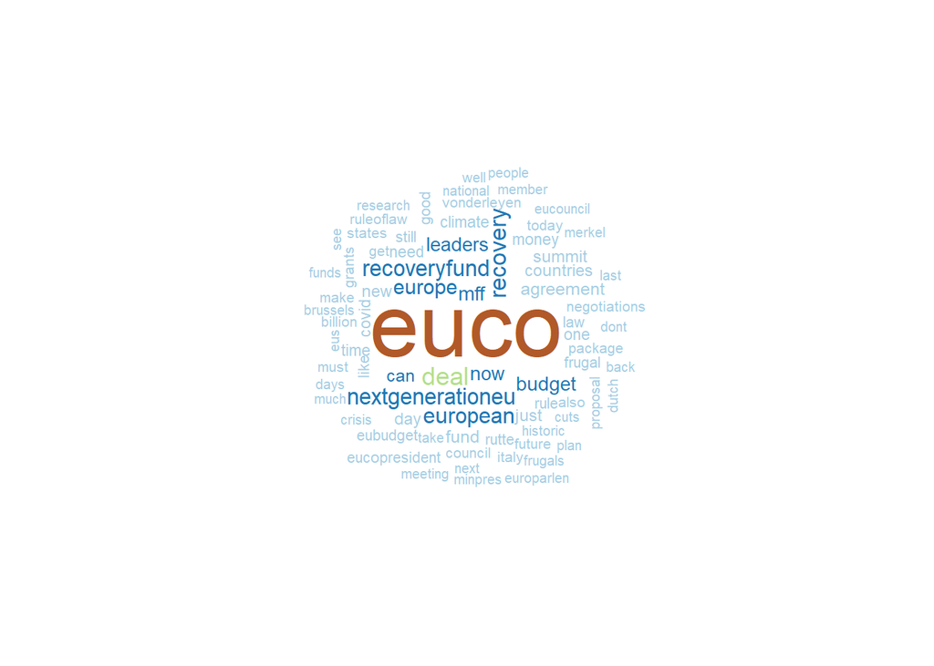

```r
wordcloud(EUCO_corpus, min.freq = 200, random.order = FALSE, colors = brewer.pal(12, "Paired"))
```

## Nube de Polaridad

En esta ocasión representamos una nube de palabras con polaridad. Es decir, divididas en dos polos uno con carácter negativo y el otro positivo.

```r
# Transform the text to a tidy data structure with one token per row
EUCO_TT <- as.data.frame(EUCO_corpus$content)
tokens <- EUCO_TT %>%
  mutate(dialogue=EUCO_corpus$content) %>%
  unnest_tokens(word, dialogue)
```

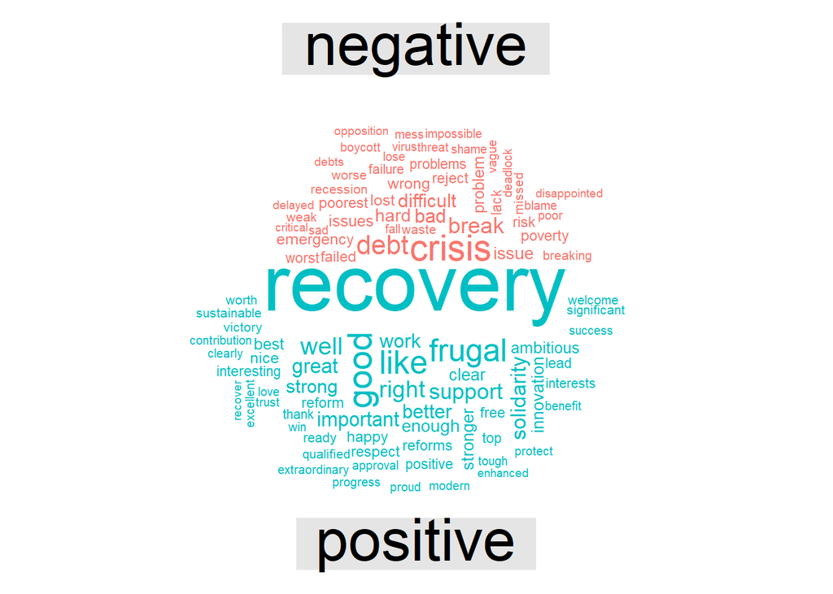

```r
# Positive and negative words
#install.packages("reshape2")

tokens %>%
  inner_join(get_sentiments("bing")) %>%
  count(word, sentiment, sort=TRUE) %>%
  acast(word ~ sentiment, value.var="n", fill=0) %>%
  comparison.cloud(colors=c("#F8766D", "#00BFC4"), max.words=100)
```

## Comparativa tweets españoles

Comparamos con la nube de palabras y de polaridad de twitteros en español.

```r
#En vez de sacar los datos de Twitter, podemos cargar el fichero
load("./data/NextGenerationEU_EUCO_RF_nrtw_es_2020-07-25.RData")
EUCO_text <- EUCO_tweets$text
```

Definimos la función *spain.rm* para eliminar los acentos y la ‘ñ’ en tweets en español.

```r
spain.rm <- function(x){
  # Quito todos los acento para tener menos dificultades con la nube de palabras
  # Cambio la ñ porque de problemas en la nube
  x <- gsub("á", "a", x)
  x <- gsub("é", "e", x)
  x <- gsub("í", "i", x)
  x <- gsub("ó", "o", x)
  x <- gsub("ú", "u", x)
  x <- gsub("ñ", "n", x)
}
```

Eliminamos caracteres españoles de los tweets, limpiamos los tweets y creamos un corpus para representar la nube de palabras y posterior polaridad siguiendo los mismos pasos que para los tweets en inglés.

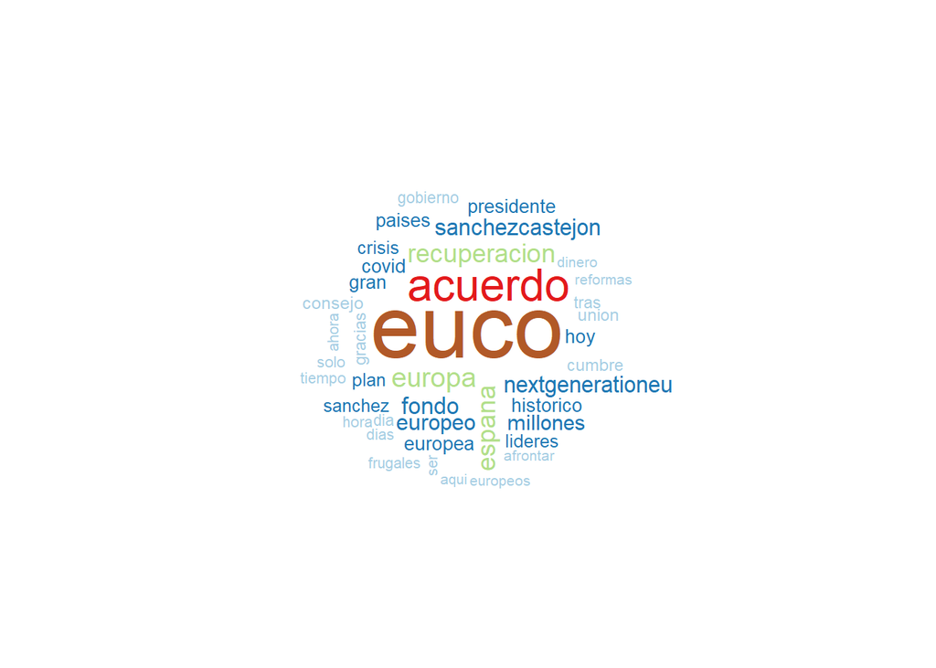

```r
#Limpiamos tweets
EUCO_text <- tolower(tweets.clean(spain.rm(EUCO_text)))

#Creamos corpus y lo limpiamos
EUCO_corpus <- Corpus(VectorSource(EUCO_text))
stopwords <- spain.rm(stopwords::stopwords("es"))
EUCO_corpus <- corpus.clean(EUCO_corpus)

# wordcloud
wordcloud(EUCO_corpus, min.freq = 100, random.order = FALSE, colors = brewer.pal(12, "Paired"))
```

En los tweets en español, destacan términos como *euco, acuerdo, europa, espana, sanchez, millones, recuperacion, historico*. Aparentemente, se centra más en temas monetarios y de ayuda, aunque menciona reforma, covid y gracias.

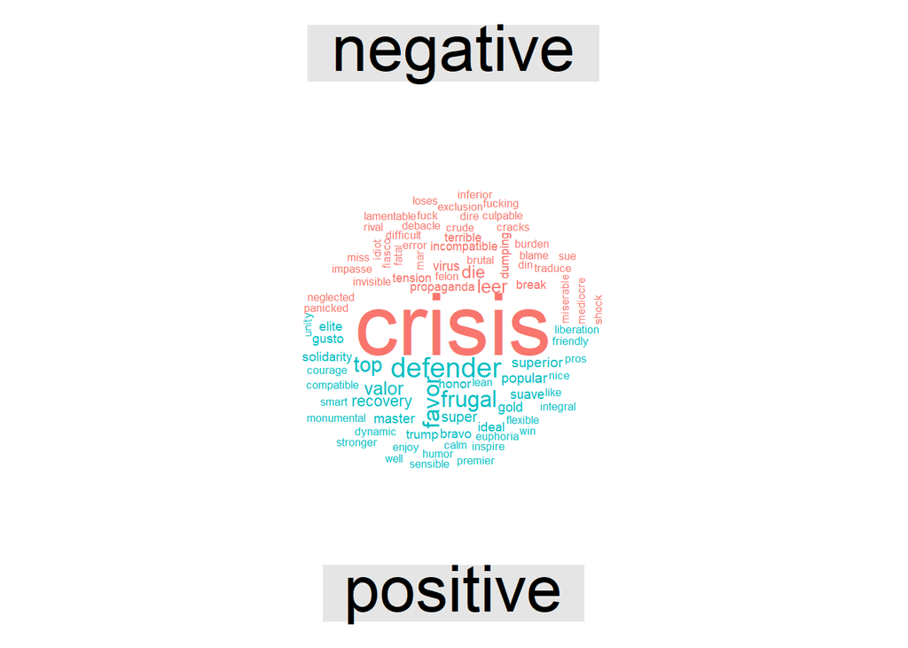

```r
# Transform the text to a tidy data structure with one token per row
EUCO_TT <- as.data.frame(EUCO_corpus$content)
tokens <- EUCO_TT %>%
  mutate(dialogue=EUCO_corpus$content) %>%
  unnest_tokens(word, dialogue)


# Positive and negative words

tokens %>%
  inner_join(get_sentiments("bing")) %>%
  count(word, sentiment, sort=TRUE) %>%
  acast(word ~ sentiment, value.var="n", fill=0) %>%
  comparison.cloud(colors=c("#F8766D", "#00BFC4"), max.words=100)
```

La polaridad está también muy igualada, aunque parece ser un poco más negativa comparada con los twitteros de habla inglesa.

*Como conclusión, me gustaría mencionar que los twitteros, en especial los que se expresan en inglés, hablan en general de los términos englobados los documentos. Es decir, tienen conocimiento según este análisis del contenido tratado en los documentos publicados por la Comisión Europea y además ven aspectos más positivos que negativos.*

# Referencias

- The game is afoot! Topic modeling of Sherlock Holmes stories https://juliasilge.com/blog/sherlock-holmes-stm/
- Text Mining with R: https://www.tidytextmining.com/
- R documentation https://www.rdocumentation.org/packages/stm/versions/1.3.5/topics/stm
- stackoverflow: https://stackoverflow.com/
- Santiago Mota: Material de Máster en Big data & business analytics (Módulo Text Mining)
[^1]: tm: Feinerer http://tm.r-forge.r-project.org/
[^2]: stm: MIT http://structuraltopicmodel.com/ by Margaret Roberts & others
[^3]: Recovery Instrument to support the recovery in the aftermath of the COVID-19: https://data.consilium.europa.eu/doc/document/ST-8141-2020-REV-1/en/pdf
[^4]: Expresiones regulares (https://www.geeksforgeeks.org/write-regular-expressions/)
[^5]: European Council euco final conclusions: https://www.consilium.europa.eu//media/45109/210720-euco-final-conclusions-en.pdf
[^6]: Tweeter API funcion search: (https://developer.twitter.com/en/docs/tweets/search/api-reference/get-search-tweets)

Realizado por: [Jose Antonio Espejel Muñoz](https://www.linkedin.com/in/joey-espejel-b4bb0238/)